# Lab3 - Linear Regression

Santiago Liscovsky

1 November 2017

#### 1) Use R to estimate the unknown parameters of the hypothesised model. Find the least squares estimates of the slope ${\hat\beta}_1$ and intercept ${\hat\beta}_0$ on the printout. Write down the least squares equation for this model.

```r
lm.fit = lm(damage_y~distance_x)
lm.fit
```

[output not shown]

```
##
## Call:
## lm(formula = damage_y ~ distance_x)
##
## Coefficients:
## (Intercept)   distance_x
##      10.278        4.919
```

#### 2) Plot the dataset and the least squares line on the same figure.

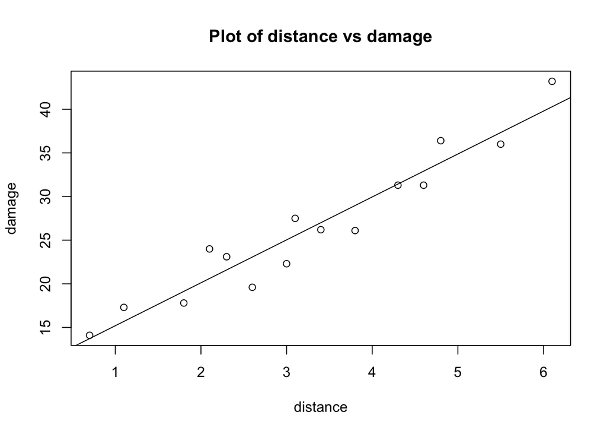

```r
plot(distance_x, damage_y, xlab="distance", ylab = "damage", main = "Plot of distance vs damage")
abline(lm.fit)
```

#### 3) How to interpret the slope ${\hat\beta}_1$ and y-intercept ${\hat\beta}_0$ of the least squares line?

the y-intercept with value 10.278, we can say that from initial cost for damage will be ${\hat\beta}_0$ Besides, for every toushand miles the cost for damage is 4.919.

#### 4) Which model fits the data. a) What is the RSE of this model? How to interpret it? b) what the is the R-suared value? How to interpret it

```r
summary(lm.fit)
```

[output not shown]

```
##
## Call:
## lm(formula = damage_y ~ distance_x)
##
## Residuals:
##     Min      1Q  Median      3Q     Max
## -3.4682 -1.4705 -0.1311  1.7915  3.3915
##
## Coefficients:
##             Estimate Std. Error t value Pr(>|t|)
## (Intercept)  10.2779     1.4203   7.237 6.59e-06 ***
## distance_x    4.9193     0.3927  12.525 1.25e-08 ***
## ---
## Signif. codes:  0 '***' 0.001 '**' 0.01 '*' 0.05 '.' 0.1 ' ' 1
##
## Residual standard error: 2.316 on 13 degrees of freedom
## Multiple R-squared:  0.9235, Adjusted R-squared:  0.9176
## F-statistic: 156.9 on 1 and 13 DF,  p-value: 1.248e-08
```